# Exploratory Data Analysis of Red Wine

Marco Rodriguez

December 2, 2018

```
##   X fixed.acidity volatile.acidity citric.acid residual.sugar chlorides
## 1 1           7.4             0.70        0.00            1.9     0.076
## 2 2           7.8             0.88        0.00            2.6     0.098
## 3 3           7.8             0.76        0.04            2.3     0.092
## 4 4          11.2             0.28        0.56            1.9     0.075
## 5 5           7.4             0.70        0.00            1.9     0.076
## 6 6           7.4             0.66        0.00            1.8     0.075
##   free.sulfur.dioxide total.sulfur.dioxide density   pH sulphates alcohol
## 1                  11                   34  0.9978 3.51      0.56     9.4
## 2                  25                   67  0.9968 3.20      0.68     9.8
## 3                  15                   54  0.9970 3.26      0.65     9.8
## 4                  17                   60  0.9980 3.16      0.58     9.8
## 5                  11                   34  0.9978 3.51      0.56     9.4
## 6                  13                   40  0.9978 3.51      0.56     9.4
##   quality
## 1       5
## 2       5
## 3       5
## 4       6
## 5       5
## 6       5
```

```
##        X          fixed.acidity   volatile.acidity  citric.acid
##  Min.   :   1.0   Min.   : 4.60   Min.   :0.1200   Min.   :0.000
##  1st Qu.: 400.5   1st Qu.: 7.10   1st Qu.:0.3900   1st Qu.:0.090
##  Median : 800.0   Median : 7.90   Median :0.5200   Median :0.260
##  Mean   : 800.0   Mean   : 8.32   Mean   :0.5278   Mean   :0.271
##  3rd Qu.:1199.5   3rd Qu.: 9.20   3rd Qu.:0.6400   3rd Qu.:0.420
##  Max.   :1599.0   Max.   :15.90   Max.   :1.5800   Max.   :1.000
##  residual.sugar     chlorides       free.sulfur.dioxide
##  Min.   : 0.900   Min.   :0.01200   Min.   : 1.00
##  1st Qu.: 1.900   1st Qu.:0.07000   1st Qu.: 7.00
##  Median : 2.200   Median :0.07900   Median :14.00
##  Mean   : 2.539   Mean   :0.08747   Mean   :15.87
##  3rd Qu.: 2.600   3rd Qu.:0.09000   3rd Qu.:21.00
##  Max.   :15.500   Max.   :0.61100   Max.   :72.00
##  total.sulfur.dioxide    density             pH          sulphates
##  Min.   :  6.00       Min.   :0.9901   Min.   :2.740   Min.   :0.3300
##  1st Qu.: 22.00       1st Qu.:0.9956   1st Qu.:3.210   1st Qu.:0.5500
##  Median : 38.00       Median :0.9968   Median :3.310   Median :0.6200
##  Mean   : 46.47       Mean   :0.9967   Mean   :3.311   Mean   :0.6581
##  3rd Qu.: 62.00       3rd Qu.:0.9978   3rd Qu.:3.400   3rd Qu.:0.7300
##  Max.   :289.00       Max.   :1.0037   Max.   :4.010   Max.   :2.0000
##     alcohol         quality
##  Min.   : 8.40   Min.   :3.000
##  1st Qu.: 9.50   1st Qu.:5.000
##  Median :10.20   Median :6.000
##  Mean   :10.42   Mean   :5.636
##  3rd Qu.:11.10   3rd Qu.:6.000
##  Max.   :14.90   Max.   :8.000
```

```
## [1] 1599   13
```

```
##  [1] "X"                    "fixed.acidity"        "volatile.acidity"
##  [4] "citric.acid"          "residual.sugar"       "chlorides"
##  [7] "free.sulfur.dioxide"  "total.sulfur.dioxide" "density"
## [10] "pH"                   "sulphates"            "alcohol"
## [13] "quality"
```

# Univariate Plots Section

## Histograms to show the distribution of the variable values:

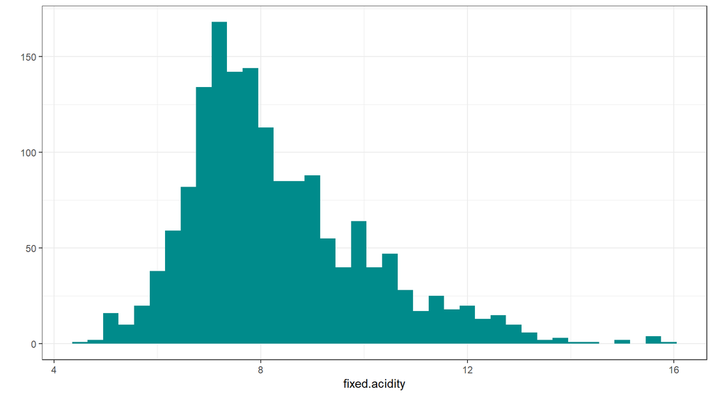

```
##    Min. 1st Qu.  Median    Mean 3rd Qu.    Max.
##    4.60    7.10    7.90    8.32    9.20   15.90
```

> Max values for fixed acidity is 15.90 and min is 4.60. There are some outliers

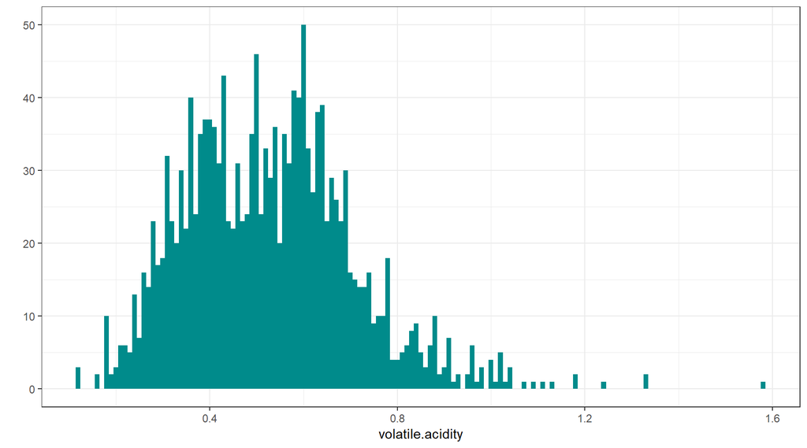

```
##    Min. 1st Qu.  Median    Mean 3rd Qu.    Max.
##  0.1200  0.3900  0.5200  0.5278  0.6400  1.5800
```

> Max value is 1.58 and min 0.12. There are some outliers.

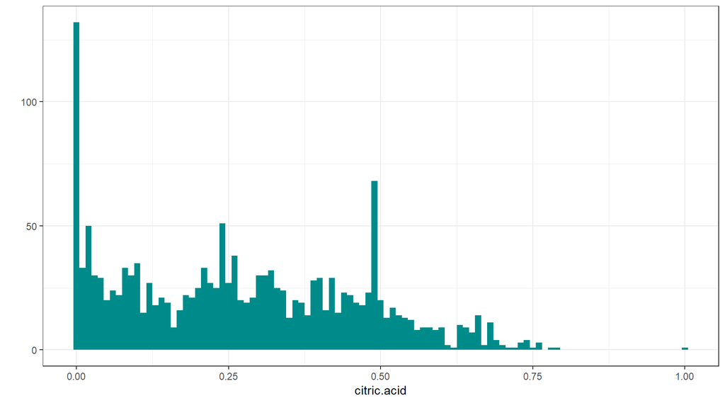

```
##    Min. 1st Qu.  Median    Mean 3rd Qu.    Max.
##   0.000   0.090   0.260   0.271   0.420   1.000
```

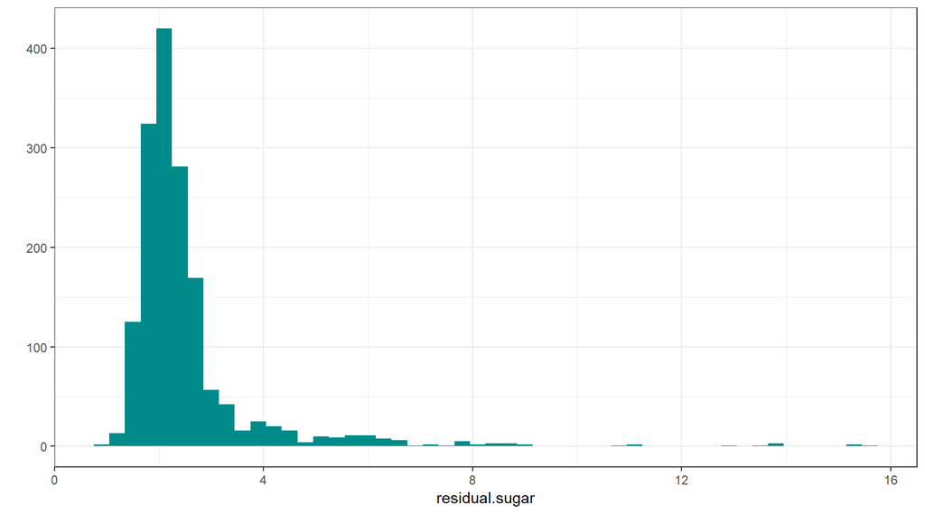

```
##    Min. 1st Qu.  Median    Mean 3rd Qu.    Max.
##   0.900   1.900   2.200   2.539   2.600  15.500
```

> We notice an irregular shape for residual.sugar. Max value is 15.50 and min 0.900. There are some outliers.

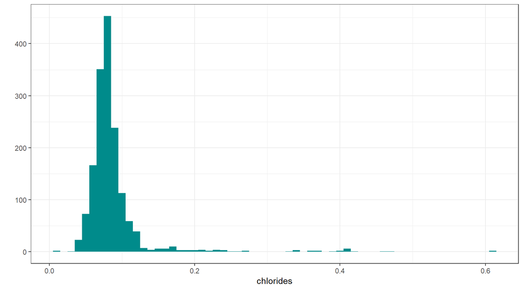

```
##    Min. 1st Qu.  Median    Mean 3rd Qu.    Max.
## 0.01200 0.07000 0.07900 0.08747 0.09000 0.61100
```

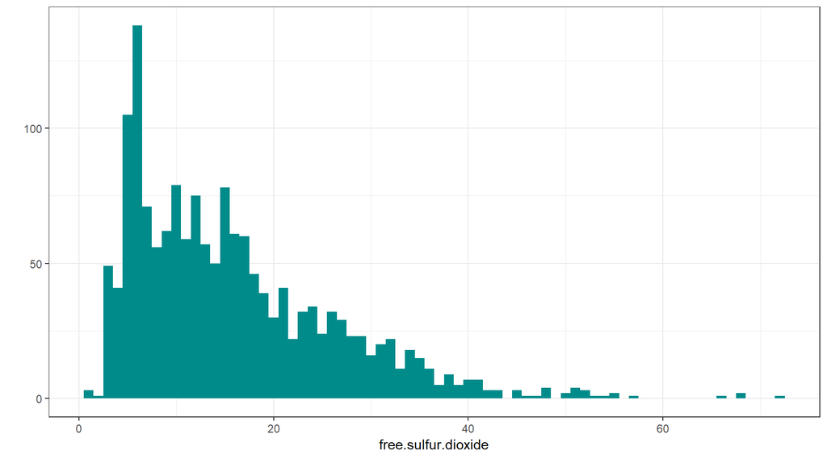

```
##    Min. 1st Qu.  Median    Mean 3rd Qu.    Max.
##    1.00    7.00   14.00   15.87   21.00   72.00
```

> There are some outliers. Most value count are found within 2 and 20

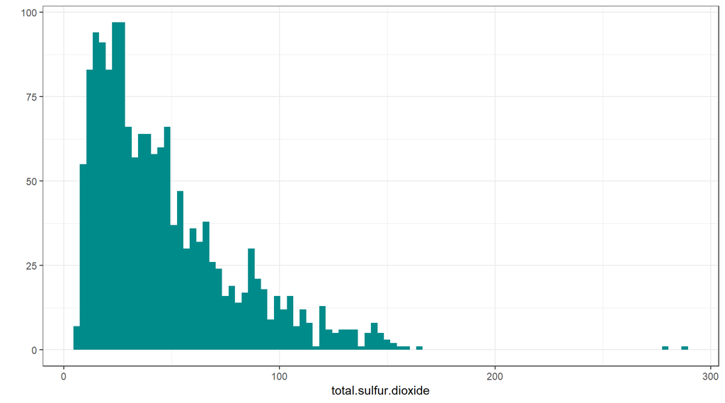

```
##    Min. 1st Qu.  Median    Mean 3rd Qu.    Max.
##    6.00   22.00   38.00   46.47   62.00  289.00
```

> Plot seens right skewed. There are some outliers. Max value is 289 and min 6.00

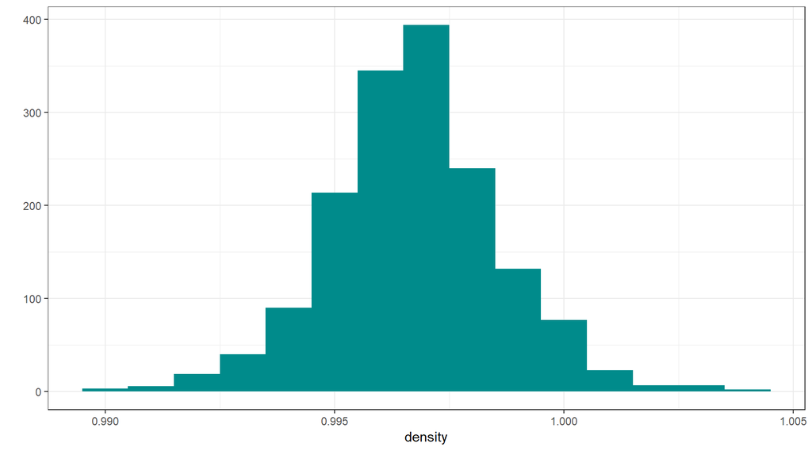

```
##    Min. 1st Qu.  Median    Mean 3rd Qu.    Max.
##  0.9901  0.9956  0.9968  0.9967  0.9978  1.0037
```

> Plot seens normal distribute. Max value is 1.0037 and min 0.9901

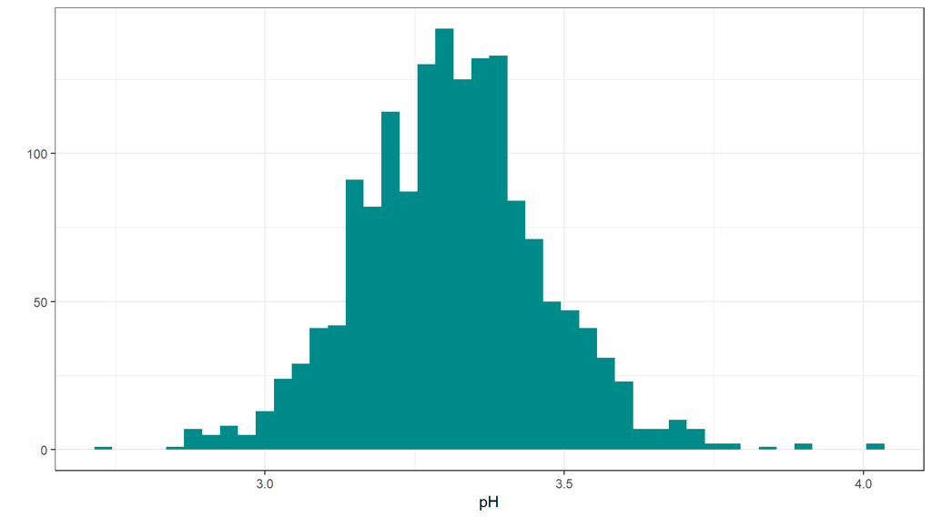

```
##    Min. 1st Qu.  Median    Mean 3rd Qu.    Max.
##   2.740   3.210   3.310   3.311   3.400   4.010
```

> Plot seems noral distribute with some outliers.

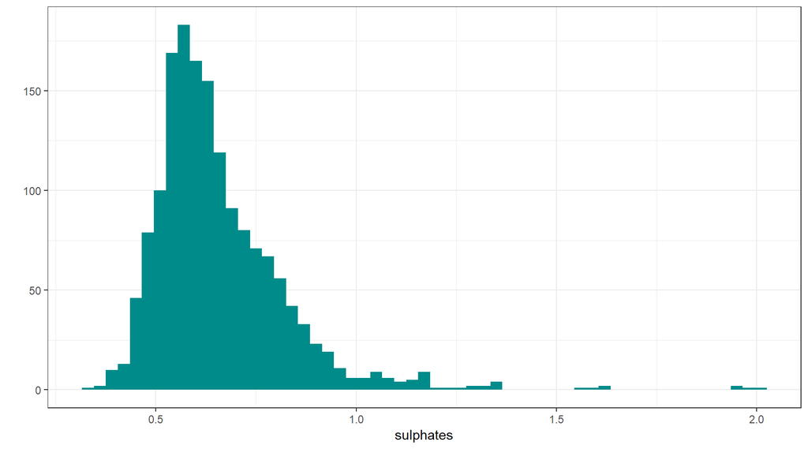

```
##    Min. 1st Qu.  Median    Mean 3rd Qu.    Max.
##  0.3300  0.5500  0.6200  0.6581  0.7300  2.0000
```

> There are some outliers. Most value count fall within 0.3 and 0.9.

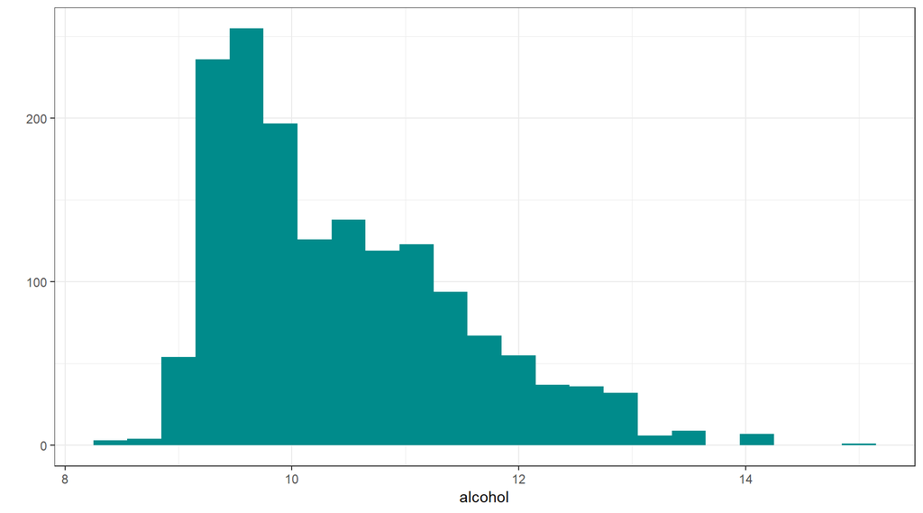

```
##    Min. 1st Qu.  Median    Mean 3rd Qu.    Max.
##    8.40    9.50   10.20   10.42   11.10   14.90
```

> Plot seems right skewed. There are some outliers.

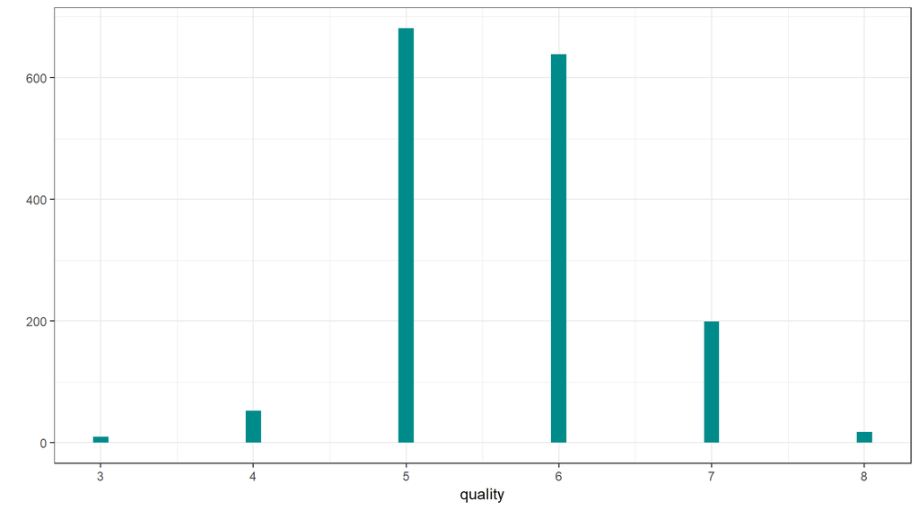

```
##    Min. 1st Qu.  Median    Mean 3rd Qu.    Max.
##   3.000   5.000   6.000   5.636   6.000   8.000
```

## Observations regarding variables:

> Residual sugar has a positive skewed distribution.

> Fixed acidity, volatile acidity, free sulphur dioxide, density and citric acid have outliers.

# Univariate Analysis

### What is the structure of your dataset?

> 1599 observation and 13 variables or characteristics.

### What is/are the main feature(s) of interest in your dataset?

> Quality is one of my main characteristic. The quality of a wine is closely linked to its properties such as alcohol, density, pH.

### What other features in the dataset do you think will help support your investigation into your feature(s) of interest?

> Other features in the data set that will help support the investigation are are alcohol content, pH and density.

### Did you create any new variables from existing variables in the dataset?

> Yes, a new categorical variable called qc.cat to classify the wines into categories according to the quality value for each register.

### Of the features you investigated, were there any unusual distributions? Did you perform any operations on the data to tidy, adjust, or change the form of the data? If so, why did you do this?

> Alcohol, volatile.acidity, citric.acid, residual.sugar, ph has an irregular shaped distribution. No, I didn’t.

# Bivariate Plots Section

> After doing some research on the internet. Red wine quality is affect by his alcohol level, acidity, density, and pH.

## Plots for the main feature(s) of interest (Alcohol, sulphates, density, citric.acid, fixed.acidity)

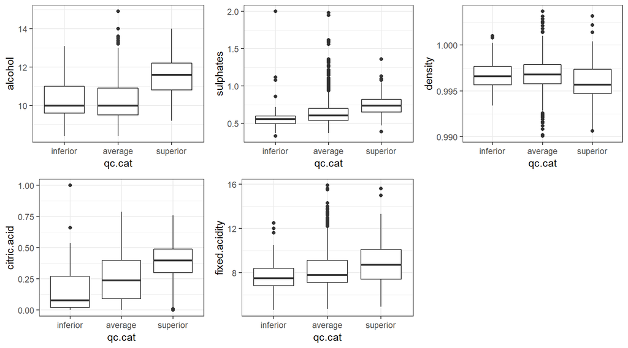

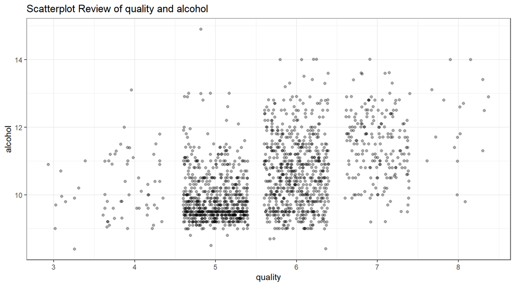

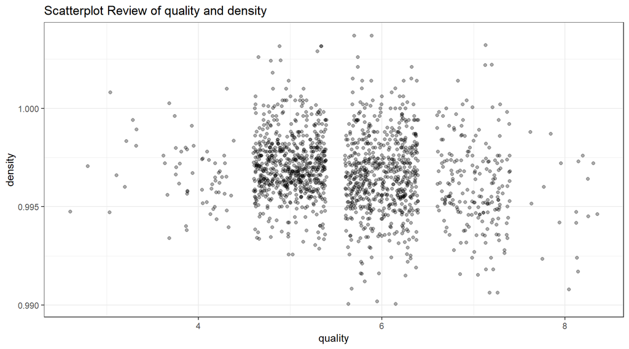

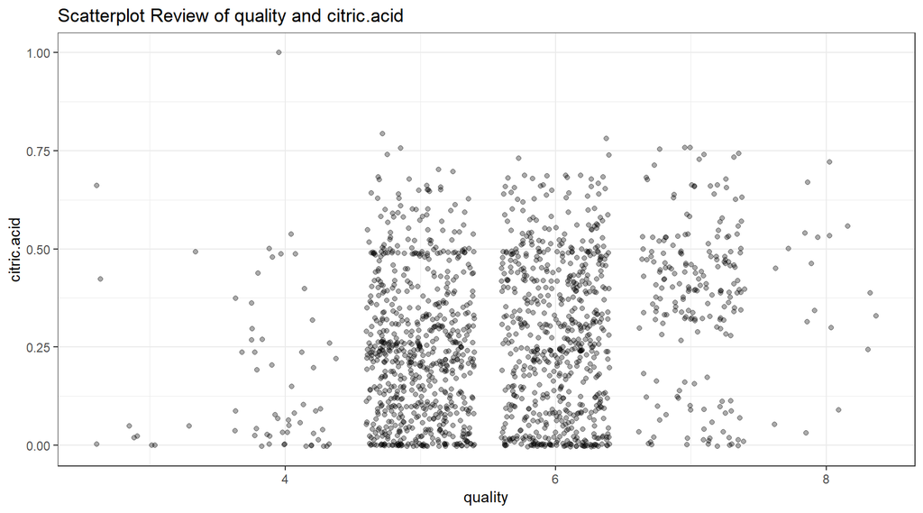

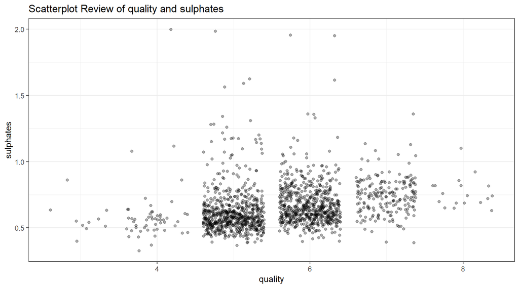

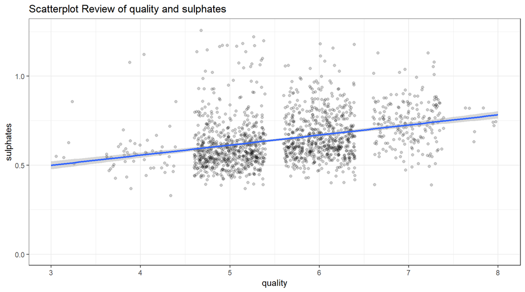

> sulphates increases the quality of wine.

## Plots for not the main feature(s) of interest (pH, residual.sugar, chlorides, free.sulfur.dioxide, total.sulfur.dioxide)

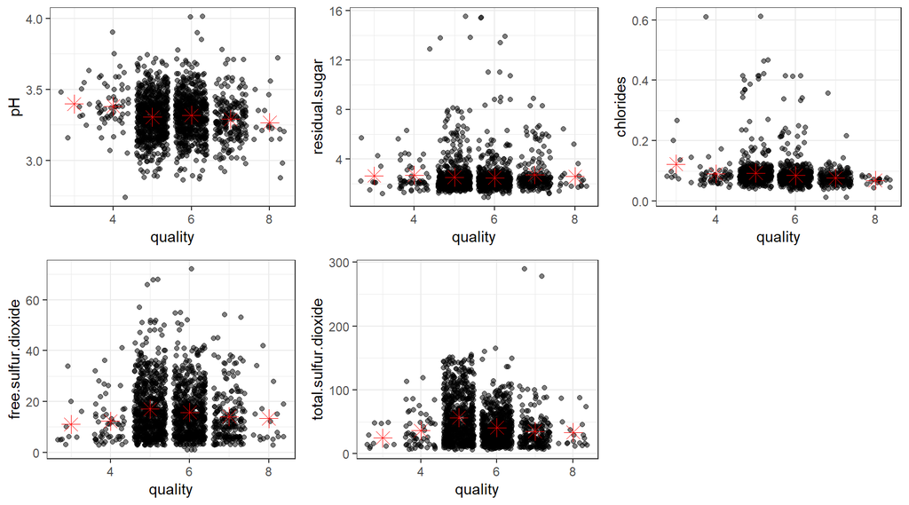

> As we can see in the plots above these features have some correlation with important wine features. It is noticible that cat 5 and cat6 have the concentration of those variables.

### Correlation between Chemical Attributes

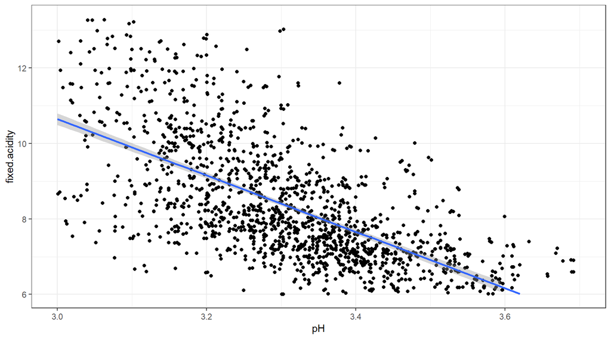

```
##
##  Pearson's product-moment correlation
##
## data:  rwine$pH and rwine$fixed.acidity
## t = -37.366, df = 1597, p-value < 2.2e-16
## alternative hypothesis: true correlation is not equal to 0
## 95 percent confidence interval:
##  -0.7082857 -0.6559174
## sample estimates:
##        cor
## -0.6829782
```

> It is noticible that fixed.acidity and pH have a negative correlation. When fixed.acidity increase ph levels decrease.

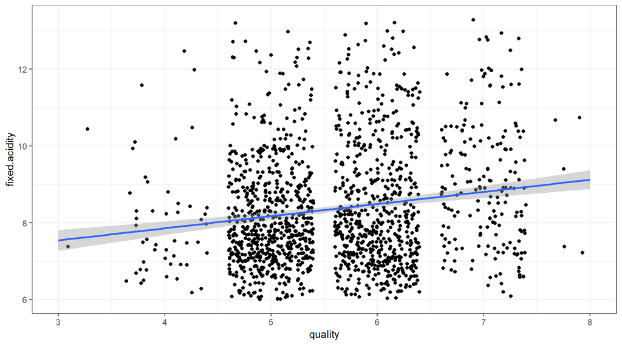

```
##
##  Pearson's product-moment correlation
##
## data:  rwine$quality and rwine$fixed.acidity
## t = 4.996, df = 1597, p-value = 6.496e-07
## alternative hypothesis: true correlation is not equal to 0
## 95 percent confidence interval:
##  0.07548957 0.17202667
## sample estimates:
##       cor
## 0.1240516
```

> There is positive correlation between fixed.acidity and quality. As the fixed.acidity increase quality gets better.

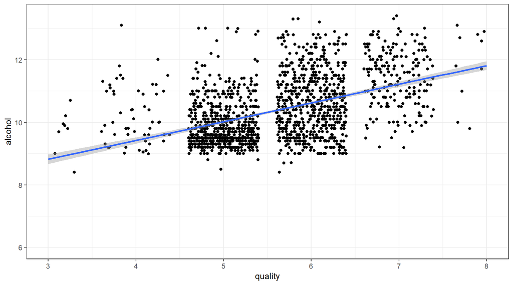

```
##
##  Pearson's product-moment correlation
##
## data:  rwine$quality and rwine$alcohol
## t = 21.639, df = 1597, p-value < 2.2e-16
## alternative hypothesis: true correlation is not equal to 0
## 95 percent confidence interval:
##  0.4373540 0.5132081
## sample estimates:
##       cor
## 0.4761663
```

> It is clear that higher the alcohol content the better the quality gets.

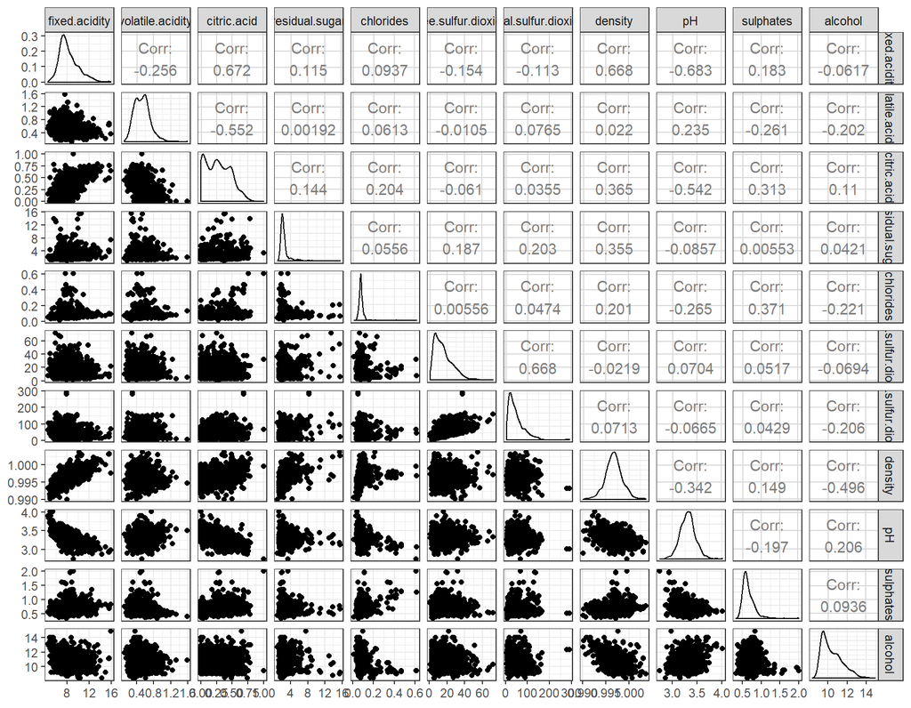

> The highest positive correlatoin is between [fixed.acidity, density] and [fixed.acidity, citric.acid]

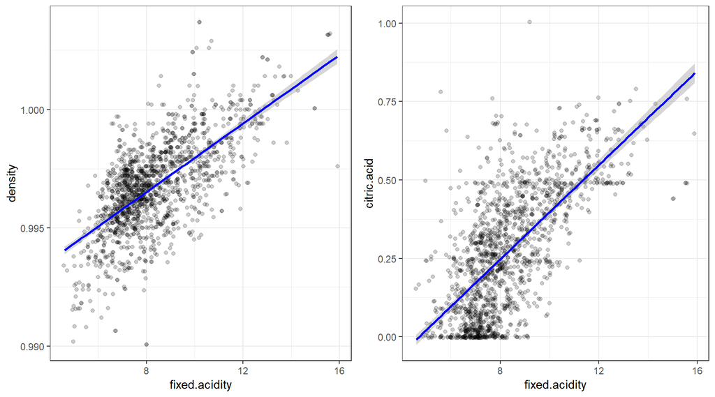

> As ggpais showed us, there is a positive correlation between [fixed.acidity, density] and [fixed.acidity, citric.acid]

[output not shown]

```
##
##  Pearson's product-moment correlation
##
## data:  rwine$quality and rwine$pH
## t = -2.3109, df = 1597, p-value = 0.02096
## alternative hypothesis: true correlation is not equal to 0
## 95 percent confidence interval:
##  -0.106451268 -0.008734972
## sample estimates:
##         cor
## -0.05773139
```

[output not shown]

```
##
##  Pearson's product-moment correlation
##
## data:  rwine$quality and rwine$density
## t = -7.0997, df = 1597, p-value = 1.875e-12
## alternative hypothesis: true correlation is not equal to 0
## 95 percent confidence interval:
##  -0.2220365 -0.1269870
## sample estimates:
##        cor
## -0.1749192
```

[output not shown]

```
##
##  Pearson's product-moment correlation
##
## data:  rwine$quality and rwine$fixed.acidity
## t = 4.996, df = 1597, p-value = 6.496e-07
## alternative hypothesis: true correlation is not equal to 0
## 95 percent confidence interval:
##  0.07548957 0.17202667
## sample estimates:
##       cor
## 0.1240516
```

```
## [1] "fixed.acidity and density"
```

```
##
##  Pearson's product-moment correlation
##
## data:  rwine$fixed.acidity and rwine$density
## t = 35.877, df = 1597, p-value < 2.2e-16
## alternative hypothesis: true correlation is not equal to 0
## 95 percent confidence interval:
##  0.6399847 0.6943302
## sample estimates:
##       cor
## 0.6680473
```

```
## [1] "fixed.acidity and citric.acid"
```

```
##
##  Pearson's product-moment correlation
##
## data:  rwine$fixed.acidity and rwine$citric.acid
## t = 36.234, df = 1597, p-value < 2.2e-16
## alternative hypothesis: true correlation is not equal to 0
## 95 percent confidence interval:
##  0.6438839 0.6977493
## sample estimates:
##       cor
## 0.6717034
```

# Bivariate Analysis

## Observations regarding variables from plots:

### Talk about some of the relationships you observed in this part of the investigation. How did the feature(s) of interest vary with other features in the dataset?

> Negative correlation [pH, fixed.acidity], [Density, Alcohol],

# Multivariate Plots Section

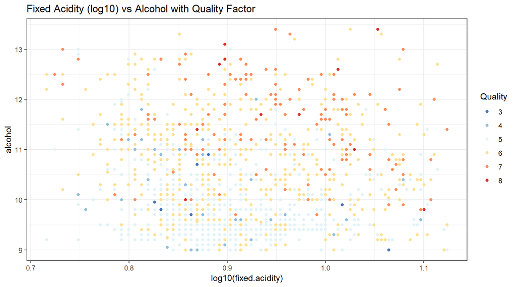

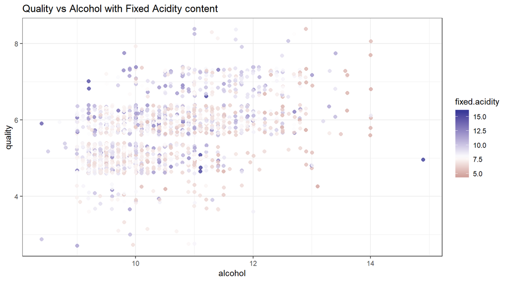

> Wines that have higher levels of fixed.acidity have better quality than those with low fixed.acidity.

# Multivariate Analysis

### Talk about some of the relationships you observed in this part of the investigation. Were there features that strengthened each other in terms of looking at your feature(s) of interest?

> Fixed.acidity, volatile.acidity, citric.acidity, and alcohol can be used to predict the quality of the wines. Due the positive correlation I think the best thin k to do is to create a linear model to properly prdeict the wine quality.

### Were there any interesting or surprising interactions between features?

> It was kind of surprising that wine quality increase with the acidicy and alcohol levels.

### OPTIONAL: Did you create any models with your dataset? Discuss the strengths and limitations of your model.

> R-square and P-value in the linear regression will help determine quality of the wine

## Regression Model

```
##
## Calls:
## m1: lm(formula = quality ~ alcohol * volatile.acidity * citric.acid *
##     fixed.acidity, data = rwine)
## m2: lm(formula = quality ~ alcohol + volatile.acidity + citric.acid +
##     fixed.acidity + density + alcohol:volatile.acidity + alcohol:citric.acid +
##     volatile.acidity:citric.acid + alcohol:fixed.acidity + volatile.acidity:fixed.acidity +
##     citric.acid:fixed.acidity + fixed.acidity:density + alcohol:volatile.acidity:citric.acid +
##     alcohol:volatile.acidity:fixed.acidity + alcohol:citric.acid:fixed.acidity +
##     volatile.acidity:citric.acid:fixed.acidity + alcohol:volatile.acidity:citric.acid:fixed.acidity,
##     data = rwine)
## m3: lm(formula = quality ~ alcohol + volatile.acidity + citric.acid +
##     fixed.acidity + density + sulphates + alcohol:volatile.acidity +
##     alcohol:citric.acid + volatile.acidity:citric.acid + alcohol:fixed.acidity +
##     volatile.acidity:fixed.acidity + citric.acid:fixed.acidity +
##     fixed.acidity:density + alcohol:volatile.acidity:citric.acid +
##     alcohol:volatile.acidity:fixed.acidity + alcohol:citric.acid:fixed.acidity +
##     volatile.acidity:citric.acid:fixed.acidity + alcohol:volatile.acidity:citric.acid:fixed.acidity,
##     data = rwine)
## m4: lm(formula = quality ~ alcohol + volatile.acidity + citric.acid +
##     fixed.acidity + density + sulphates + pH + total.sulfur.dioxide +
##     free.sulfur.dioxide + alcohol:volatile.acidity + alcohol:citric.acid +
##     volatile.acidity:citric.acid + alcohol:fixed.acidity + volatile.acidity:fixed.acidity +
##     citric.acid:fixed.acidity + fixed.acidity:density + pH:total.sulfur.dioxide +
##     pH:free.sulfur.dioxide + total.sulfur.dioxide:free.sulfur.dioxide +
##     alcohol:volatile.acidity:citric.acid + alcohol:volatile.acidity:fixed.acidity +
##     alcohol:citric.acid:fixed.acidity + volatile.acidity:citric.acid:fixed.acidity +
##     pH:total.sulfur.dioxide:free.sulfur.dioxide + alcohol:volatile.acidity:citric.acid:fixed.acidity,
##     data = rwine)
##
## ====================================================================================================================
##                                                                  m1            m2            m3            m4
## --------------------------------------------------------------------------------------------------------------------
##   (Intercept)                                                  25.660***    -89.059       -49.960       -40.479
##                                                                (5.261)      (53.714)      (53.155)      (53.803)
##   alcohol                                                      -1.846***     -1.705***     -1.698***     -1.639***
##                                                                (0.481)       (0.485)       (0.477)       (0.474)
##   volatile.acidity                                            -43.800***    -43.562***    -42.806***    -43.058***
##                                                                (9.750)       (9.749)       (9.597)       (9.553)
##   citric.acid                                                 -67.590***    -68.839***    -68.794***    -70.622***
```

[output cut: 42 more lines]

```
##                                                                                                          (0.001)
##   pH x total.sulfur.dioxide x free.sulfur.dioxide                                                        -0.001***
##                                                                                                          (0.000)
## --------------------------------------------------------------------------------------------------------------------
##   R-squared                                                     0.344         0.346         0.367         0.381
##   adj. R-squared                                                0.338         0.339         0.360         0.372
##   sigma                                                         0.657         0.657         0.646         0.640
##   F                                                            55.374        49.230        50.843        38.783
##   p                                                             0.000         0.000         0.000         0.000
##   Log-likelihood                                            -1589.406     -1586.971     -1561.317     -1542.718
##   Deviance                                                    683.520       681.442       659.923       644.748
##   AIC                                                        3212.812      3211.942      3162.634      3139.435
##   BIC                                                        3304.223      3314.107      3270.177      3284.618
##   N                                                          1599          1599          1599          1599
## ====================================================================================================================
```

# Final Plots and Summary

### Plot One

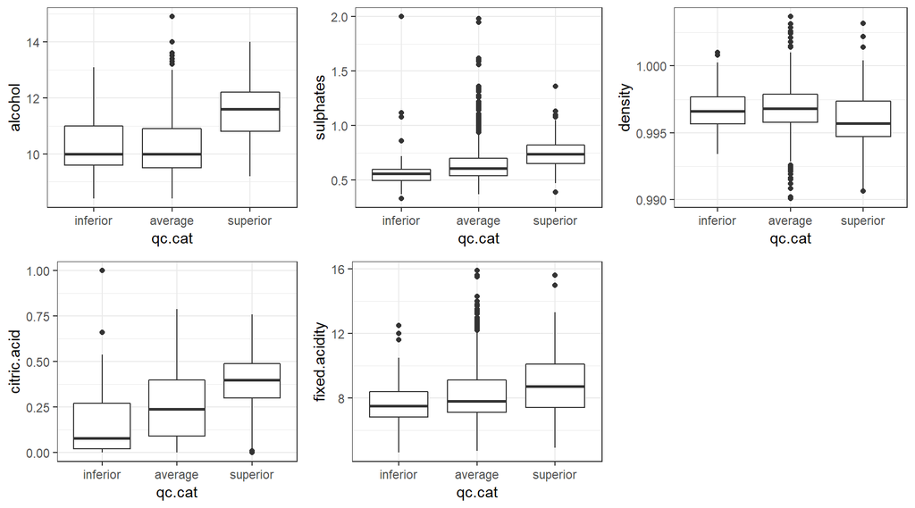

### Plot Two

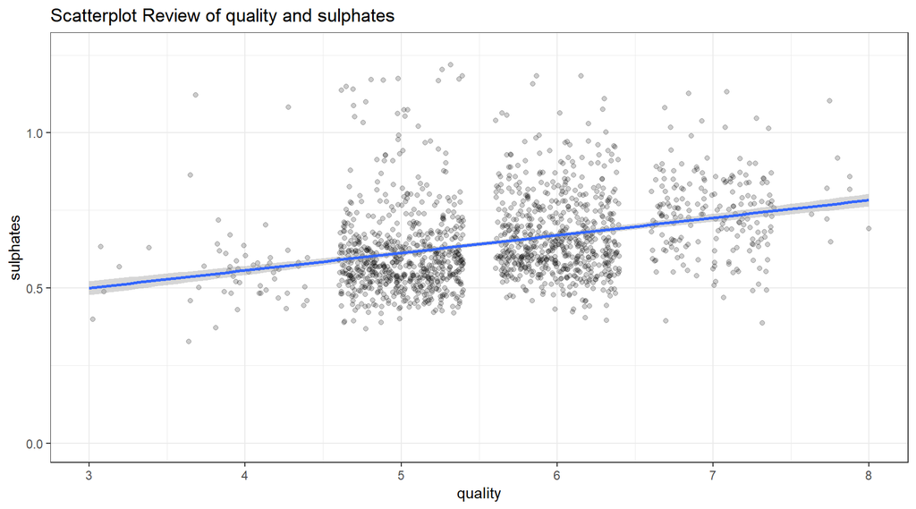

### Description Two

> There is a positive correlation between sulphates and quality. When the sulphates values increase the wine quality increases too.

### Plot Three

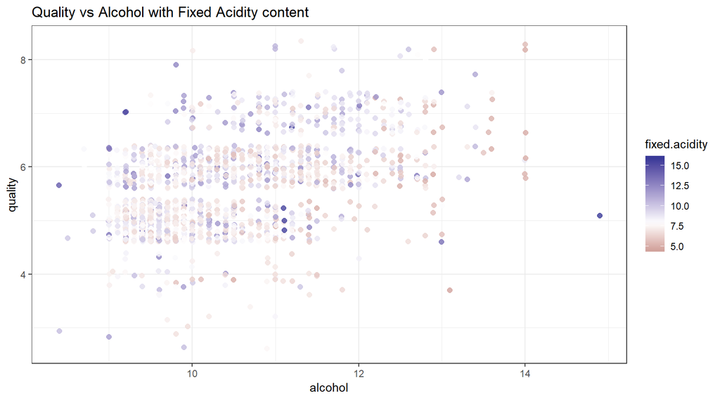

### Description Three

> The plot above show us that wines with cat 5 and cat 6 high values of fixed acidity.

# Reflection

The Red wine data set contains information about 1,599 red wines with 11 features. The analysis started by analysing individuals features in the red wine data set. The analysis revealed that alcohol, sulphates, and fixed.acidity are key features for determining wine’s quality. High alcohol level and low concentration of volatile acidity are a good combination for red wine. Most frequent quality levels are cat5 and cat6. May be beauce of price too?. Exmining the correlations guided me to understand certains relations between features such as fixed.acidy and alcohol.

I always thouht that alcohol content was a key feature when measuring the quality of the wines. After the analysis, sulphates and acidity are also playing an important role in determining wine’s quality.

Some limitations, the dataset are only variants of the Portuguese “Vinho Verde” wine. There is no data about grape types, wine brand, wine selling price, etc.